# Problem Set 4

This assignment is the first part of problem set 4 of the Udacity course *Data Analysis with R* lesson 4: *Explore Two Variables*. This part of the problem set consists in a set of questions/tasks answered below.

### Diamonds

Load the diamonds dataset

```r
library(ggplot2)
data(diamonds)
str(diamonds)
```

```
## 'data.frame':    53940 obs. of  10 variables:
##  $ carat  : num  0.23 0.21 0.23 0.29 0.31 0.24 0.24 0.26 0.22 0.23 ...
##  $ cut    : Ord.factor w/ 5 levels "Fair"<"Good"<..: 5 4 2 4 2 3 3 3 1 3 ...
##  $ color  : Ord.factor w/ 7 levels "D"<"E"<"F"<"G"<..: 2 2 2 6 7 7 6 5 2 5 ...
##  $ clarity: Ord.factor w/ 8 levels "I1"<"SI2"<"SI1"<..: 2 3 5 4 2 6 7 3 4 5 ...
##  $ depth  : num  61.5 59.8 56.9 62.4 63.3 62.8 62.3 61.9 65.1 59.4 ...
##  $ table  : num  55 61 65 58 58 57 57 55 61 61 ...
##  $ price  : int  326 326 327 334 335 336 336 337 337 338 ...
##  $ x      : num  3.95 3.89 4.05 4.2 4.34 3.94 3.95 4.07 3.87 4 ...
##  $ y      : num  3.98 3.84 4.07 4.23 4.35 3.96 3.98 4.11 3.78 4.05 ...
##  $ z      : num  2.43 2.31 2.31 2.63 2.75 2.48 2.47 2.53 2.49 2.39 ...
```

### price vs. x (length in mm)

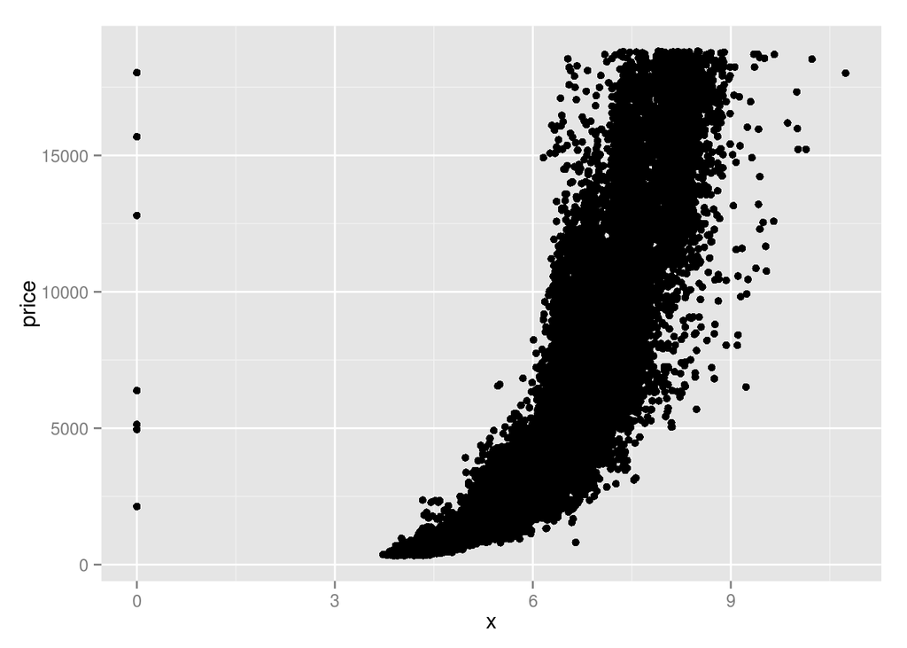

```r
ggplot(aes(x = x, y = price), data = diamonds) +
  geom_point()
```

#### Observations

Most of the diamonds have between 3 and 9 mm. The price increases rapidly with the value of x, in what seems to be a exponential relationship. There are some outliers of length 0, probably not the real value of length.

### Correlations

#### What is the correlation between price and x?

```r
cor.test(diamonds$x, diamonds$price)
```

```
##
##  Pearson's product-moment correlation
##
## data:  diamonds$x and diamonds$price
## t = 440.1594, df = 53938, p-value < 2.2e-16
## alternative hypothesis: true correlation is not equal to 0
## 95 percent confidence interval:
##  0.8825835 0.8862594
## sample estimates:
##       cor
## 0.8844352
```

0.88

#### What is the correlation between price and y?

```r
cor.test(diamonds$y, diamonds$price)
```

```
##
##  Pearson's product-moment correlation
##
## data:  diamonds$y and diamonds$price
## t = 401.1415, df = 53938, p-value < 2.2e-16
## alternative hypothesis: true correlation is not equal to 0
## 95 percent confidence interval:
##  0.8632867 0.8675241
## sample estimates:
##       cor
## 0.8654209
```

0.87

#### What is the correlation between price and z?

```r
cor.test(diamonds$z, diamonds$price)
```

```
##
##  Pearson's product-moment correlation
##
## data:  diamonds$z and diamonds$price
## t = 393.6015, df = 53938, p-value < 2.2e-16
## alternative hypothesis: true correlation is not equal to 0
## 95 percent confidence interval:
##  0.8590541 0.8634131
## sample estimates:
##       cor
## 0.8612494
```

0.86

### price vs. depth (total depth percentage)

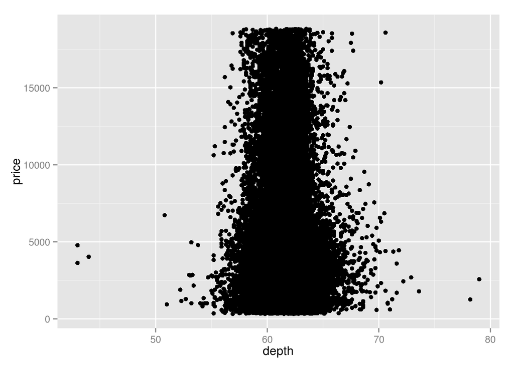

```r
ggplot(aes(x = depth , y = price), data = diamonds) +
  geom_point()
```

#### Adjustments - price vs. depth

Plot with adjusted scale, based on the summary statistics, and points with alpha channel of 1/100.

```r
summary(diamonds$depth)
```

```
##    Min. 1st Qu.  Median    Mean 3rd Qu.    Max.
##   43.00   61.00   61.80   61.75   62.50   79.00
```

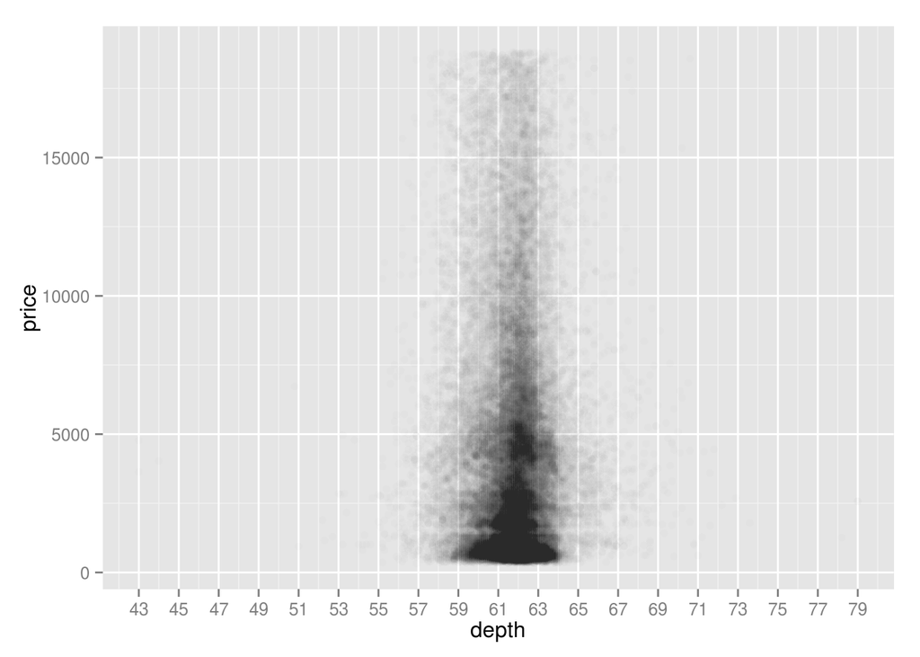

```r
ggplot(aes(x = depth , y = price), data = diamonds) +
  geom_point(alpha = 1/100) +
  scale_x_continuous(breaks = seq(43,80, 2))
```

#### Based on the scatter plot of depth vs. price, most diamonds are between what values of depth?

Between 59 - 64.

#### Correlation - price vs. depth

```r
cor.test(diamonds$depth, diamonds$price)
```

```
##
##  Pearson's product-moment correlation
##
## data:  diamonds$depth and diamonds$price
## t = -2.473, df = 53938, p-value = 0.0134
## alternative hypothesis: true correlation is not equal to 0
## 95 percent confidence interval:
##  -0.019084756 -0.002208537
## sample estimates:
##        cor
## -0.0106474
```

-0.01  
The value is close to 0 which indicates an extremely weak / nonexistent relationship between the two values.

#### Based on the correlation coefficient would you use depth to predict the price of diamonds?

No, the depth doesn’t describe the price in a way that we can predict it’s price based on a function (linear, exponential, etc..).

### price vs. carat

Create a scatter plot of price vs carat and omit the top 1% of price and carat values.

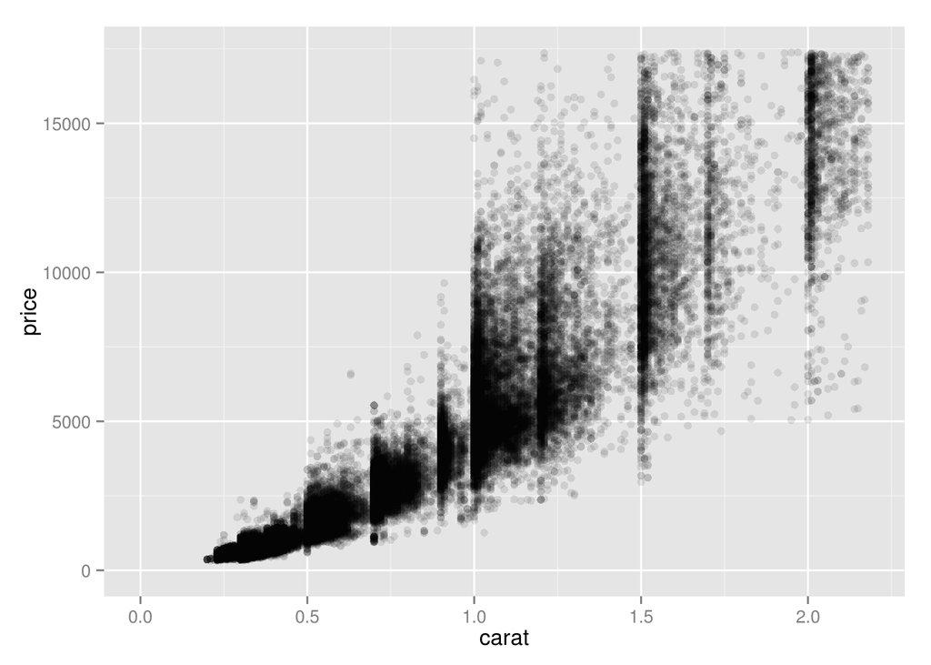

```r
ggplot(aes(x = carat, y = price), data = diamonds) +
  geom_point(alpha = 1/10) +
  xlim(0, quantile(diamonds$carat, 0.99)) +
  ylim(0, quantile(diamonds$price, 0.99))
```

### price vs. volume

Create a scatter plot of price vs. volume (x * y * z). This is a very rough approximation for a diamond’s volume.  
Create a new variable for volume in the diamonds data frame.

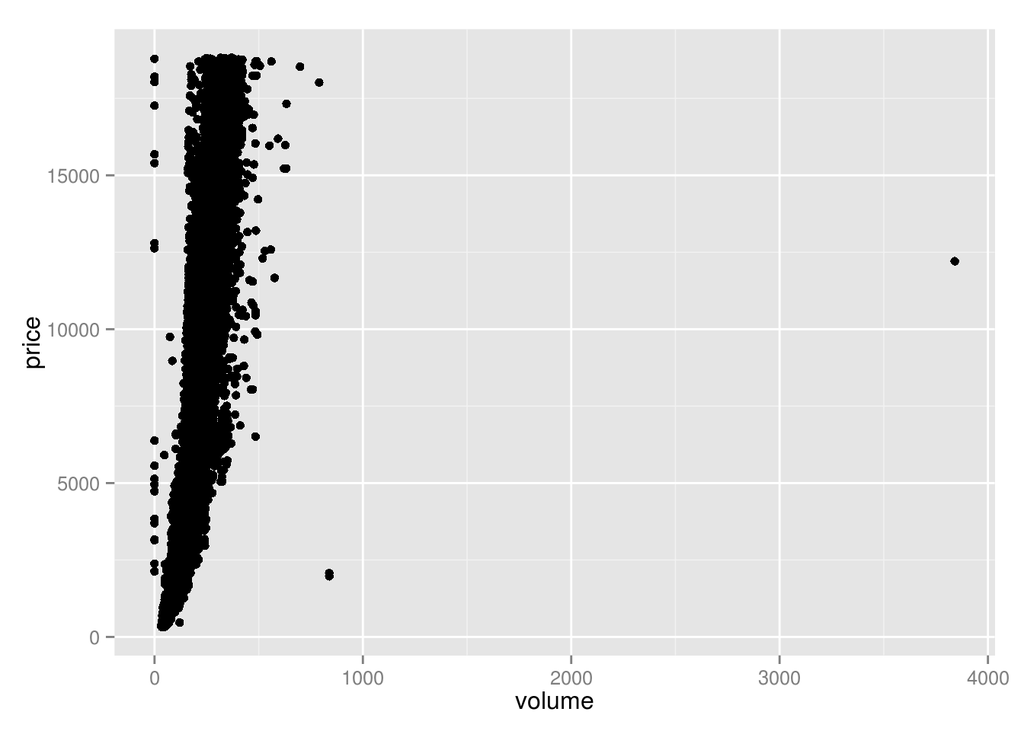

```r
diamonds$volume <- diamonds$x * diamonds$y * diamonds$z

ggplot(aes(x = volume, y = price), data = diamonds) +
  geom_point()
```

#### Observations

Volume is mostly between 0+ and 500. The majority of prices seem to increase in an exponential way with volume.  
There are some outliers such as diamonds with 0 volume and diamonds with nearly 4000 in volume.

```r
suppressMessages(library(plyr))
count(diamonds$volume == 0)
```

```
##       x  freq
## 1 FALSE 53920
## 2  TRUE    20
```

```r
suppressMessages(detach("package:plyr", unload=TRUE))
```

### Correlations on Subsets

What’s the correlation of price and volume?  
Exclude diamonds that have a volume of 0 or that are greater than or equal to 800.

```r
with(subset(diamonds, volume > 0 & volume < 800), cor.test(price, volume))
```

```
##
##  Pearson's product-moment correlation
##
## data:  price and volume
## t = 559.1912, df = 53915, p-value < 2.2e-16
## alternative hypothesis: true correlation is not equal to 0
## 95 percent confidence interval:
##  0.9222944 0.9247772
## sample estimates:
##       cor
## 0.9235455
```

0.92  
This value indicates a strong positive relationship between the two values.

### Adjustments - price vs. volume

Subset the data to exclude diamonds with a volume greater than or equal to 800. Also, exclude diamonds with a volume of 0. Adjust the transparency of the points and add a linear model to the plot.

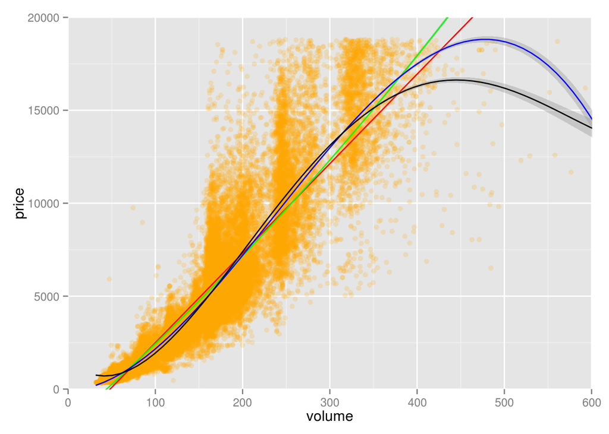

```r
ggplot(aes(x = volume, y = price),
       data = subset(diamonds, volume > 0 & volume < 800)) +
  geom_point(alpha = 1/5, color = 'orange') +
  geom_smooth(method = 'lm', color = 'red') +
  geom_smooth(method = 'lm', color = 'green', formula = y ~ poly(x,2, raw = TRUE)) +
  geom_smooth(method = 'lm', color = 'blue', formula = y ~ poly(x,3, raw = TRUE)) +
  geom_smooth(method = 'lm', color = 'black', formula = y ~poly(x,4,raw=TRUE)) +
  coord_cartesian(xlim = c(0,600), ylim=c(0,20000))
```

Red, linear model, fits the data reasonably well and is the simplest method in the graph, therefore not very expensive to use.  
The green model, $x^{2}$, blue model, $x^{3}$, and black model, $x^{4}$, seem to adapt, respectively, more accurately to the data.

### Mean Price by Clarity

Use the function *summarise* from the *dplyr* package to create a new data frame containing info on diamonds by clarity.  
Add the variables *mean_price*, *median_price*, *min_price*, *max_price* and *n*.

```r
suppressMessages(library(dplyr))
diamonds.by.clarity <- diamonds %>%
  group_by(clarity) %>%
  summarise(min_price = min(price),
            median_price = median(as.numeric(price)),
            mean_price = mean(price),
            max_price = max(price),
            n = n())

diamonds.by.clarity
```

```
## Source: local data frame [8 x 6]
##
##   clarity min_price median_price mean_price max_price     n
## 1      I1       345         3344   3924.169     18531   741
## 2     SI2       326         4072   5063.029     18804  9194
## 3     SI1       326         2822   3996.001     18818 13065
## 4     VS2       334         2054   3924.989     18823 12258
## 5     VS1       327         2005   3839.455     18795  8171
## 6    VVS2       336         1311   3283.737     18768  5066
## 7    VVS1       336         1093   2523.115     18777  3655
## 8      IF       369         1080   2864.839     18806  1790
```

### Bar Charts of Mean Price

We’ve created summary data frames with the mean price by clarity and color. You can run the code in R to verify what data is in the variables *diamonds_mp_by_clarity* and *diamonds_mp_by_color*.  
Your task is to write additional code to create two bar plots on one output image using the *grid.arrange()* function from the package *gridExtra*.

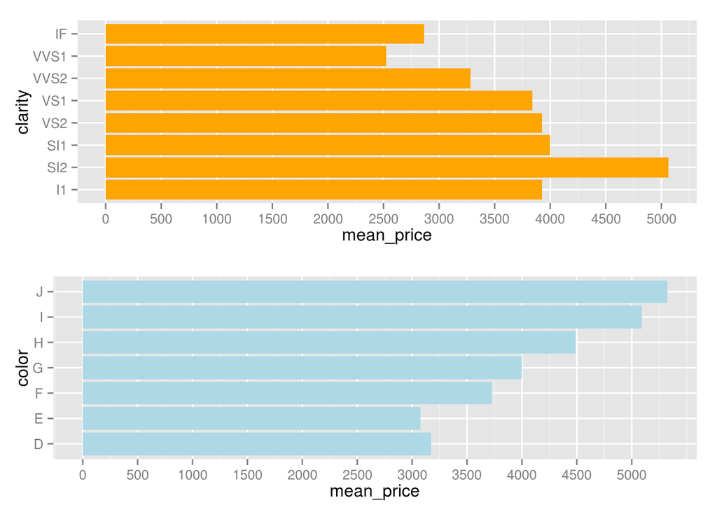

```r
diamonds_by_clarity <- group_by(diamonds, clarity)
diamonds_mp_by_clarity <- summarise(diamonds_by_clarity, mean_price = mean(price))

diamonds_by_color <- group_by(diamonds, color)
diamonds_mp_by_color <- summarise(diamonds_by_color, mean_price = mean(price))

suppressMessages(library(gridExtra))

p1 <- ggplot(aes(x = clarity, y = mean_price), data = diamonds_mp_by_clarity) +
  geom_bar(stat = 'identity', fill  = 'orange') +
  scale_y_continuous(breaks=seq(0,5200, 500)) +
  coord_flip()

p2 <- ggplot(aes(x = color, y = mean_price), data = diamonds_mp_by_color) +
  geom_bar(stat = 'identity', fill = 'light blue') +
  scale_y_continuous(breaks=seq(0,5200, 500)) +
  coord_flip()

grid.arrange(p1,p2)
```

#### Observations

Higher mean prices for color J and for clarity SI2 (both over 5000). Lower mean prices for clarity VVS1 (around 2500) and for color E and D (around 3000).  
Mean prices for color look odd since the prices are decreasing as the color type is improving. This can also be observed between some clarity levels.

Sara Carvalho 05-03-2015